# Explore discard data

Alaia

2025-02-05

WCGOP data need to be downloaded in data_provided folder from google drive # Install and load package

```r
library(ggplot2)
library(reshape2)
library(here)
library(dplyr)
require(tidyverse)
library(ggpubr)
library(remotes)
library(r4ss)
```

# Visualizing the Data

## Load and plot WCGOP data

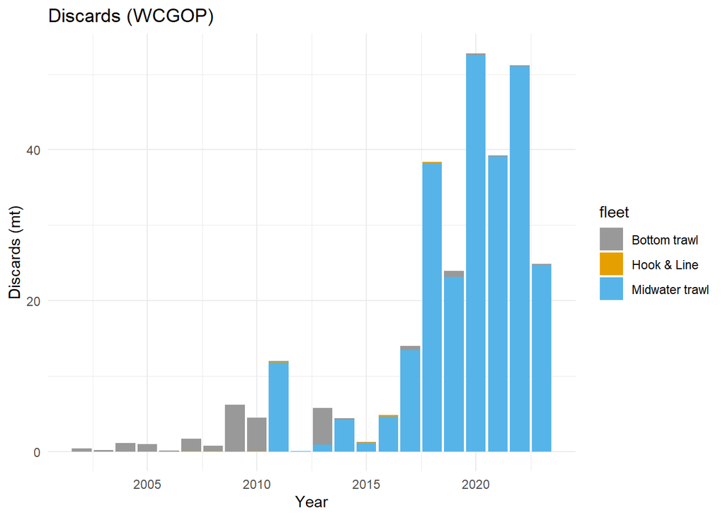

```r
data_discard_non_catch <- read.csv(here("data_provided/wcgop", "discard_rates_noncatch_share.csv")) %>%
  select(year, fleet, obs_discard) %>%
  rename(observed_discard_mt = obs_discard) %>%
  mutate(fleet = recode(fleet,
         "bottomtrawl-coastwide" = "Bottom trawl",
         "hook-and-line-coastwide" = "Hook & Line"))

data_discard_catch<- read.csv(here("data_provided/wcgop", "discard_rates_combined_catch_share.csv")) %>%
  select("year", "fleet", "observed_discard_mt")%>%
  mutate(fleet = recode(fleet,
         "bottomtrawl-coastwide" = "Bottom trawl",
         "hook-and-line-coastwide" = "Hook & Line",
         "midwaterrockfish-coastwide" = "Midwater trawl",
         "midwaterhake-coastwide" = "Midwater trawl"))

data_discard <- rbind(data_discard_non_catch, data_discard_catch)

ggplot(data_discard, aes(x = year, y = observed_discard_mt, fill = fleet)) +
  scale_fill_manual(values=c("#999999", "#E69F00", "#56B4E9"))+
  geom_col() +
  theme_minimal() +
    labs(x = "Year", y = "Discards (mt)",
       title = paste0("Discards (WCGOP)"))+
  theme(strip.text = element_text(face = "bold"))
```

## Discards length composition

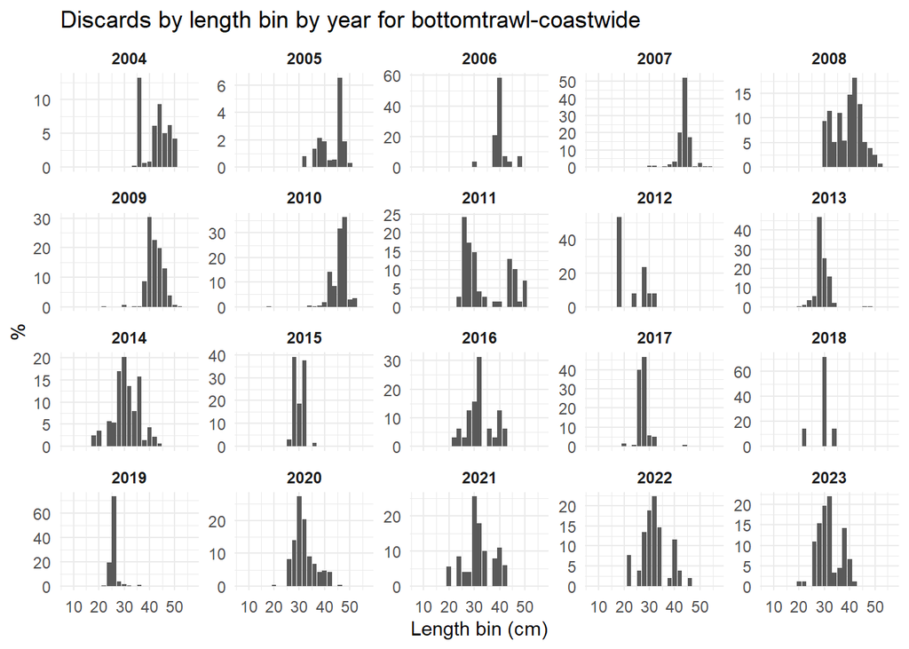

```r
data <- read.csv(here("data_provided/wcgop", "biological_discard_lengths.csv"))
data <- data[,-c(2,4,5,6,32:56)]
names(data) <- c("year", "fleet" , seq(8,56,2))
data <- melt(data, c("fleet", "year"))
data$variable = as.numeric(as.character(data$variable))

fleet_type <- unique(data$fleet)

ggplot(data[data$fleet==fleet_type[1],], aes(x = variable, y = value)) +
  geom_col() +
  facet_wrap(~ year, scales = "free_y") +
  labs(x = "Length bin (cm)", y = "%",
       title = paste0("Discards by length bin by year for ",fleet_type[1])) +
  theme_minimal() +
  theme(legend.position = "none",
        strip.text = element_text(face = "bold"))
```

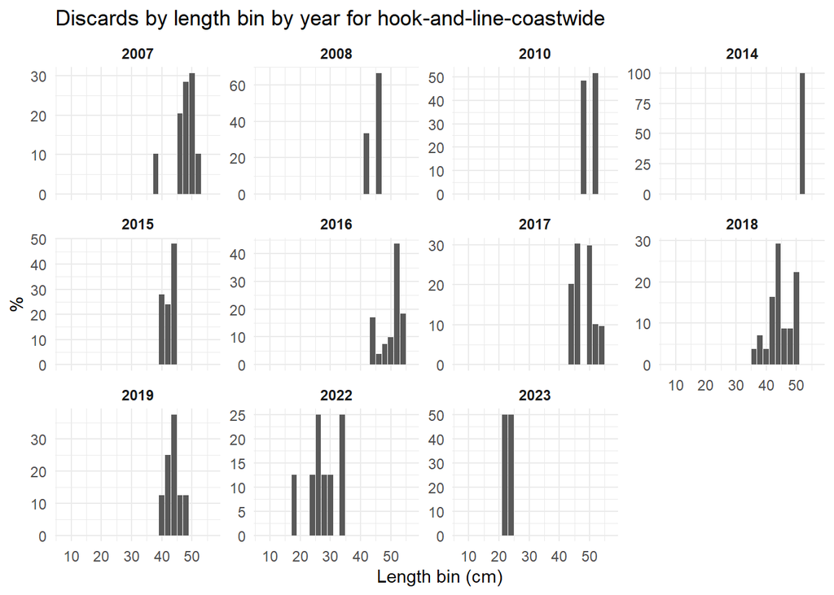

```r
ggplot(data[data$fleet==fleet_type[2],], aes(x = variable, y = value)) +
  geom_col() +
  facet_wrap(~ year, scales = "free_y") +
  labs(x = "Length bin (cm)", y = "%",
       title = paste0("Discards by length bin by year for ",fleet_type[2]))+
  theme_minimal() +
  theme(legend.position = "none",
        strip.text = element_text(face = "bold"))
```

```r
# )
```

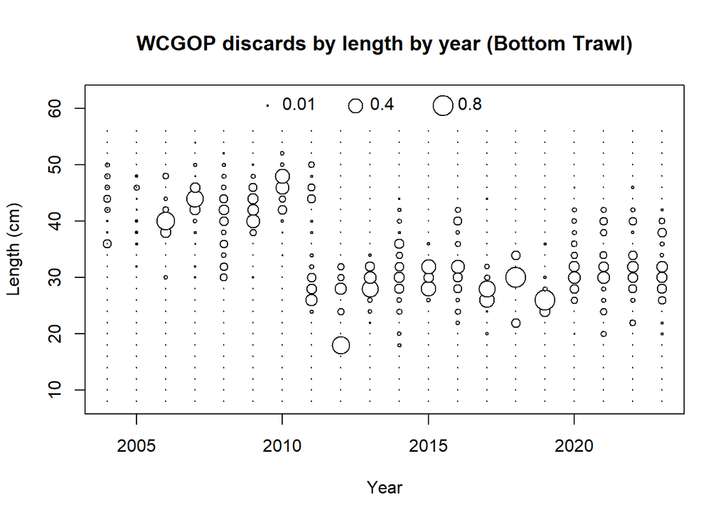

```r
# Bottom trawl
{plot(data[data$fleet==fleet_type[1],]$year, data[data$fleet==fleet_type[1],]$variable, xlab = "Year", ylab = "Length (cm)", main = "WCGOP discards by length by year (Bottom Trawl)",
     xlim = range(data[data$fleet==fleet_type[1],]$year), ylim = c(8, 62), type = "n")
symbols(data[data$fleet==fleet_type[1],]$year, data[data$fleet==fleet_type[1],]$variable, circles = sqrt(data[data$fleet==fleet_type[1],]$value/pi), inches = 0.1, add = TRUE, bg = "white")

legend_x <- 2007
legend_y <- 60
legend_sizes <- c(0.01, 0.4, 0.8) #Identical to 2019 updates
legend_circles <- sqrt(legend_sizes/pi)
symbols(legend_x-0.5 + (1:length(legend_sizes)) * 3,rep(legend_y+0.5, length(legend_sizes)) ,
        circles = legend_circles, inches = 0.1, add = TRUE, bg = "white")
text(legend_x + (1:length(legend_sizes)) * 3,rep(legend_y + 1, length(legend_sizes)) ,
     labels = legend_sizes, adj = 0)}
```

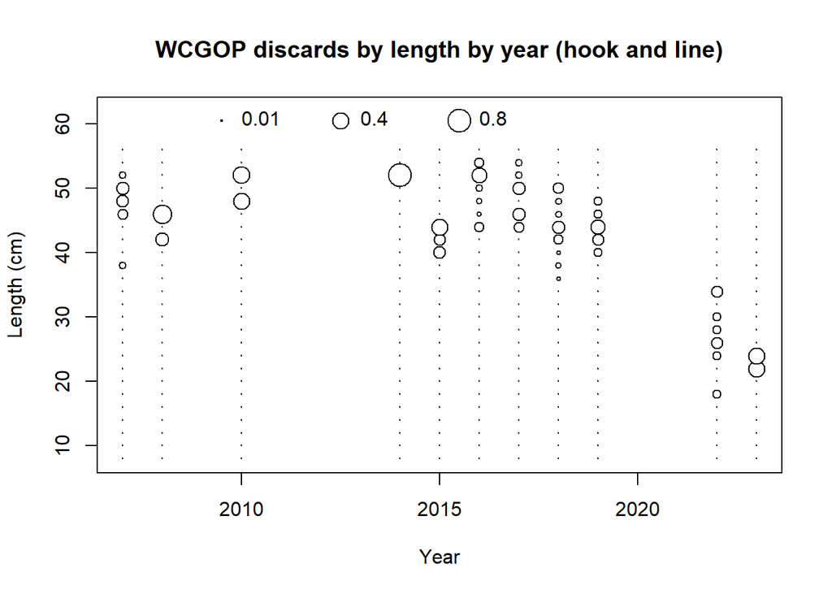

```r
# Hook & Line
{plot(data[data$fleet==fleet_type[2],]$year, data[data$fleet==fleet_type[2],]$variable, xlab = "Year", ylab = "Length (cm)", main = "WCGOP discards by length by year (hook and line)",
     xlim = range(data[data$fleet==fleet_type[2],]$year), ylim = c(8, 62), type = "n")
symbols(data[data$fleet==fleet_type[2],]$year, data[data$fleet==fleet_type[2],]$variable, circles = sqrt(data[data$fleet==fleet_type[2],]$value/pi), inches = 0.1, add = TRUE, bg = "white")

legend_x <- 2007
legend_y <- 60
legend_sizes <- c(0.01, 0.4, 0.8) #Identical to 2019 updates
legend_circles <- sqrt(legend_sizes/pi)
symbols(legend_x-0.5 + (1:length(legend_sizes)) * 3,rep(legend_y+0.5, length(legend_sizes)) ,
        circles = legend_circles, inches = 0.1, add = TRUE, bg = "white")
text(legend_x + (1:length(legend_sizes)) * 3,rep(legend_y + 1, length(legend_sizes)) ,
     labels = legend_sizes, adj = 0)}
```

## Look at ALL WCGOP discard data, regardless of fleet

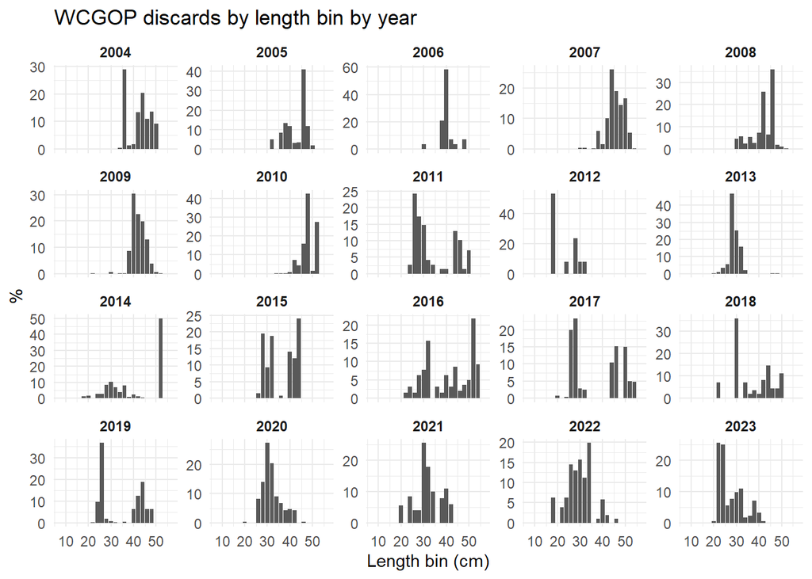

```r
data_agg <- data %>%
  group_by(year, variable) %>%
  mutate(value = sum(value)) %>%
  distinct(year, variable, value)%>%
  group_by(year)%>%
  mutate(value = value  /sum(value)*100)

ggplot(data_agg, aes(x = variable, y = value)) +
  geom_col() +
  facet_wrap(~ year, scales = "free_y") +
  labs(x = "Length bin (cm)", y = "%",
       title = paste0("WCGOP discards by length bin by year"))+
  theme_minimal() +
  theme(legend.position = "none",
        strip.text = element_text(face = "bold"))
```

```r
# Size comp by year
dev.new(width=5, height=20, unit="in")
{plot(data_agg$year, data_agg$variable, xlab = "Year", ylab = "Length (cm)", main = "WCGOP discards by length by year",
     xlim = range(data_agg$year), ylim = c(8, 62), type = "n")
symbols(data_agg$year, data_agg$variable, circles = sqrt(data_agg$value/pi), inches = 0.1, add = TRUE, bg = "white")


# Legend

legend_x <- 2007
legend_y <- 60
legend_sizes <- c(0.01, 0.4, 0.8) #Identical to 2019 updates
legend_circles <- sqrt(legend_sizes/pi)
symbols(legend_x-0.5 + (1:length(legend_sizes)) * 3,rep(legend_y+0.5, length(legend_sizes)) ,
        circles = legend_circles, inches = 0.1, add = TRUE, bg = "white")
text(legend_x + (1:length(legend_sizes)) * 3,rep(legend_y + 1, length(legend_sizes)) ,
     labels = legend_sizes, adj = 0)}
```

[output not shown]

### Prepare length composition data for .dat file

**Column order:** yr month fleet sex part Nsamp datavector(female-male)

Year = from 1985 - 2023. Data prior to WCGOP will not change (use the same as 2019 update assessment). Data beginning 2004

25 #_N_LengthBins; then enter lower edge of each length bin 8 10 12 14 16 18 20 22 24 26 28 30 32 34 36 38 40 42 44 46 48 50 52 54 56

## OPTION 1:

- Length comps from 1980’s from the 2019 .dat file
- Length comps 2004+ from new WCGOP data provided this year (2025)

```r
ssdat.2019 <- SS_readdat(file = "../data_provided/2019_assessment/2019widow.dat")
```

```
## Running SS_readdat_3.30
```

```
## Read general model dimensions.
```

```
## Read fleet information.
```

```
## Read catches.
```

```
## Read CPUE data.
```

```
## Read discards.
```

```
## Read Length composition data.
```

```
## Read age composition data.
```

```
## Read of data file complete. Final value = 999
```

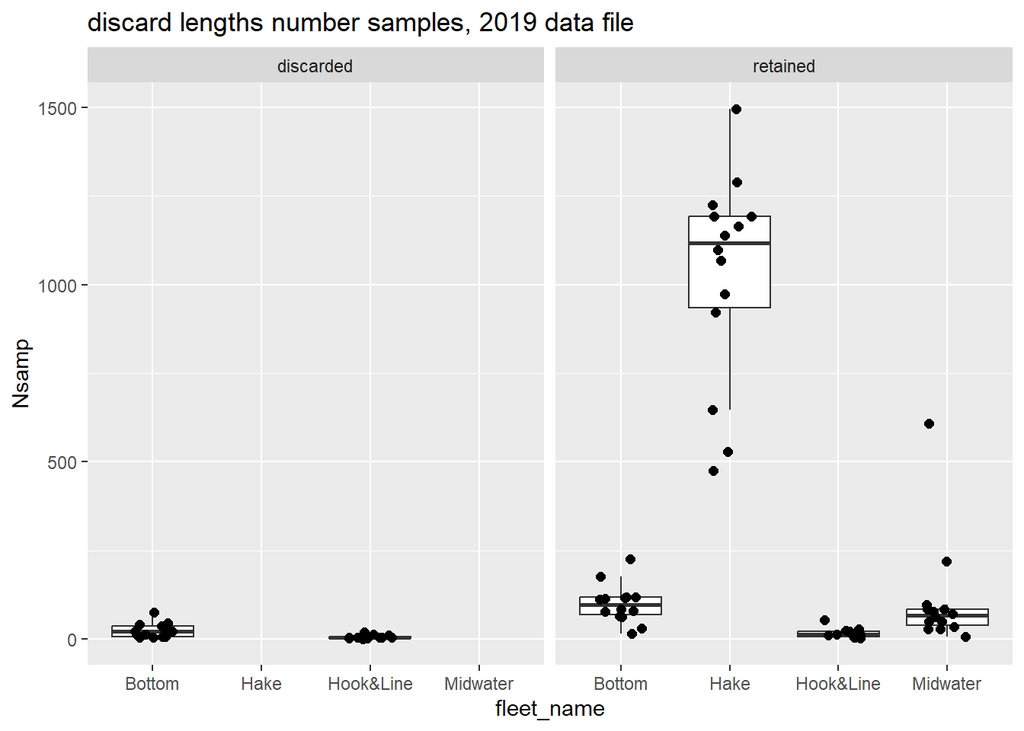

```r
# # Discard biomass
# ssdat.2019$discard_fleet_info #fleets = 1 (bottom trawl), 2 (midwater trawl), 5 (hook & line)
# ssdat.2019$discard_data #biomass

# Discard length comps - in proportion
length.comps.1980s <- ssdat.2019$lencomp %>% filter(part==1) %>% filter(year<2004 & year>0) #remove negative years

# 2019 update assessment .dat file has Botton Trawl and Hook & Line
ssdat.2019$lencomp %>%
#  filter(part==2) %>% #retained
#  filter(part==1) %>% #discarded
#  filter(part==0) %>% #combined -- fleet == 7 & 8 only, survey data
  filter(part%in%c(1,2)) %>%
  mutate(part=case_when(part==1~"discarded", part==2~"retained")) %>%
  filter(year>2004) %>%
  mutate(fleet=as.factor(as.character(fleet))) %>%
  mutate(fleet_name=case_when(
    fleet==1~"Bottom",fleet==2~"Midwater", fleet==3~"Hake", fleet==5~"Hook&Line")) %>%
  ggplot(aes(x=fleet_name, y=Nsamp)) +
  geom_boxplot(outlier.shape = NA) +
  geom_jitter(width = 0.2, size=2) +
#  theme(axis.text.x = element_text(angle = 90)) +
  facet_wrap(~part) + ggtitle("discard lengths number samples, 2019 data file")
```

```r
#  ggtitle("Number of fish measured for length comp data by fleet, WCGOP (=>2004)\n2019 .dat file")
```

Read in sample and length comps data from WCGOP, 2025 version

Here are discard samples & aggregation summary info - also only bottom trawn and hook&line data

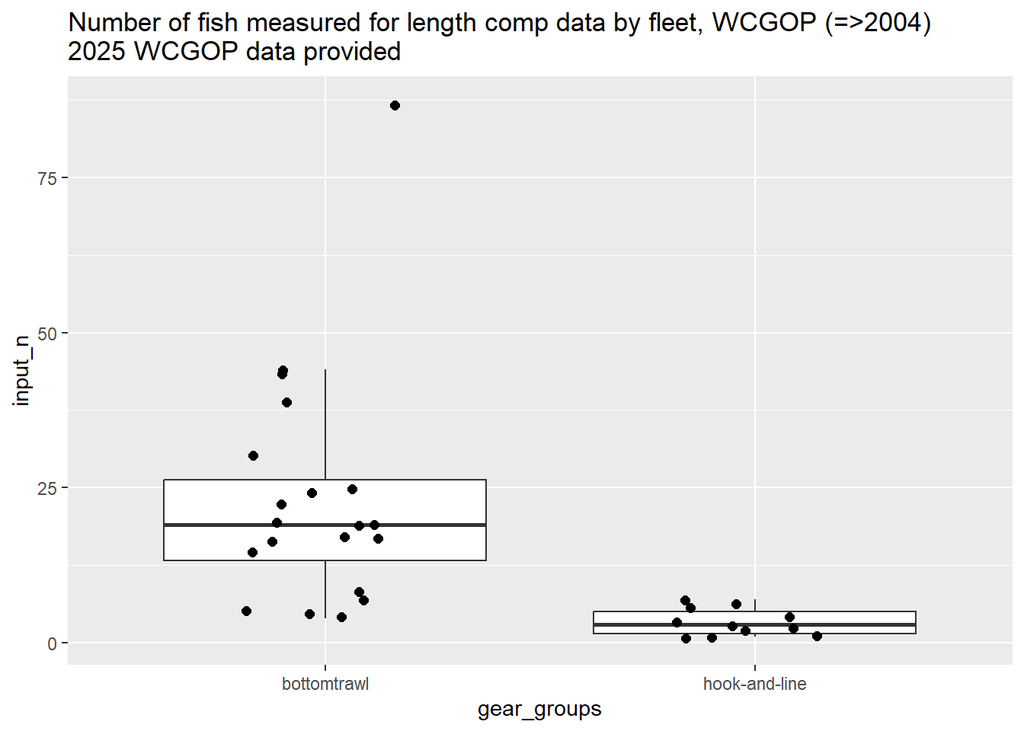

```r
length.n <- read.csv(here("data_provided/wcgop", "../wcgop/biological_sample_sizes_length.csv"))
length.n %>%
  ggplot(aes(x=gear_groups,y=input_n)) +
  geom_boxplot(outlier.shape = NA) +
  geom_jitter(width = 0.2, size=2) +
  ggtitle("Number of fish measured for length comp data by fleet, WCGOP (=>2004)\n2025 WCGOP data provided")
```

```r
# # Keeping length comps only in female bins
# length.comps.wcgop <- read.csv(here("data_provided/wcgop", "../wcgop/biological_discard_lengths.csv"), col.names = names(length.comps.1980s)) %>% #use same names as .dat from 2019 for easy row binding
#   mutate(month=7) %>%
#    mutate(across(matches("^[f|m]\\d+"), ~ . / 100)) %>% # get into proportions to match the 2019 .dat file (currently percentage)
#   mutate(fleet=case_when(
#     fleet=="bottomtrawl-coastwide"~1,
#     fleet=="midwaterrockfish-coastwide"~2,
#     fleet=="midwaterhake-coastwide"~3,
#     fleet=="hook-and-line-coastwide"~5,
#   ))


# Update April 11th, 2025
# For sex code = 0 (combined sexes) I duplicate the length comps contained in female and add to male bins (they are only in the female bins in the data from wcgop, ss manual says they need to be in both, and 2019 .dat file is formatted that way)
length.comps.wcgop.sex3 <- read.csv(here("data_provided/wcgop", "../wcgop/biological_discard_lengths.csv"), col.names = names(length.comps.1980s)) %>% #use same names as .dat from 2019 for easy row binding
  filter(sex==3)

length.comps.wcgop.sex0 <- bind_cols(
    read.csv(here("data_provided/wcgop", "biological_discard_lengths.csv"), col.names = names(length.comps.1980s)) %>% #use same names as .dat from 2019 for easy row binding
    filter(sex==0) %>% select(year:f56),
    read.csv(here("data_provided/wcgop", "biological_discard_lengths.csv"), col.names = names(length.comps.1980s)) %>% #use same names as .dat from 2019 for easy row binding
    filter(sex==0) %>% select(f8:f56) %>% rename_with(~ gsub("f", "m", .)))

legnth.comps.wcgop <- bind_rows(length.comps.wcgop.sex3, length.comps.wcgop.sex0) %>%
  mutate(month=7) %>%
  mutate(across(matches("^[f|m]\\d+"), ~ . / 100)) %>% # get into proportions to match the 2019 .dat file (currently percentage)
  mutate(fleet=case_when(
    fleet=="bottomtrawl-coastwide"~1,
    fleet=="midwaterrockfish-coastwide"~2,
    fleet=="midwaterhake-coastwide"~3,
    fleet=="hook-and-line-coastwide"~5)) %>%
  mutate(across(matches("^[f|m]\\d+"), ~ round(., 3))) #round

length.comps <- bind_rows(length.comps.1980s, legnth.comps.wcgop)

head(length.comps)
```

```
##   year month fleet sex part Nsamp f8 f10 f12 f14 f16 f18 f20 f22 f24  f26  f28
## 1 1985     7     1   1    1    85  0   0   0   0   0   0   0   0   0 0.05 0.05
## 2 1985     7     1   2    1    80  0   0   0   0   0   0   0   0   0 0.04 0.02
## 3 1986     7     1   1    1     7  0   0   0   0   0   0   0   0   0 0.05 0.05
## 4 1986     7     1   2    1     5  0   0   0   0   0   0   0   0   0 0.04 0.02
## 5 1987     7     1   1    1     1  0   0   0   0   0   0   0   0   0 0.07 0.07
## 6 1987     7     1   2    1     1  0   0   0   0   0   0   0   0   0 0.06 0.03
##    f30  f32  f34  f36  f38  f40  f42  f44  f46  f48  f50  f52 f54 f56 m8 m10
## 1 0.00 0.01 0.03 0.08 0.16 0.21 0.11 0.04 0.12 0.11 0.02 0.01   0   0  0   0
## 2 0.02 0.03 0.04 0.31 0.41 0.07 0.05 0.01 0.00 0.00 0.00 0.00   0   0  0   0
## 3 0.00 0.01 0.03 0.08 0.16 0.21 0.11 0.04 0.12 0.11 0.02 0.01   0   0  0   0
## 4 0.02 0.03 0.04 0.31 0.41 0.07 0.05 0.01 0.00 0.00 0.00 0.00   0   0  0   0
## 5 0.00 0.01 0.03 0.07 0.16 0.20 0.10 0.04 0.11 0.10 0.02 0.01   0   0  0   0
## 6 0.03 0.04 0.03 0.30 0.39 0.07 0.05 0.01 0.00 0.00 0.00 0.00   0   0  0   0
##   m12 m14 m16 m18 m20 m22 m24  m26  m28  m30  m32  m34  m36  m38  m40  m42  m44
## 1   0   0   0   0   0   0   0 0.05 0.05 0.00 0.01 0.03 0.08 0.16 0.21 0.11 0.04
## 2   0   0   0   0   0   0   0 0.04 0.02 0.02 0.03 0.04 0.31 0.41 0.07 0.05 0.01
## 3   0   0   0   0   0   0   0 0.05 0.05 0.00 0.01 0.03 0.08 0.16 0.21 0.11 0.04
## 4   0   0   0   0   0   0   0 0.04 0.02 0.02 0.03 0.04 0.31 0.41 0.07 0.05 0.01
## 5   0   0   0   0   0   0   0 0.07 0.07 0.00 0.01 0.03 0.07 0.16 0.20 0.10 0.04
## 6   0   0   0   0   0   0   0 0.06 0.03 0.03 0.04 0.03 0.30 0.39 0.07 0.05 0.01
##    m46  m48  m50  m52 m54 m56
## 1 0.12 0.11 0.02 0.01   0   0
## 2 0.00 0.00 0.00 0.00   0   0
## 3 0.12 0.11 0.02 0.01   0   0
## 4 0.00 0.00 0.00 0.00   0   0
## 5 0.11 0.10 0.02 0.01   0   0
## 6 0.00 0.00 0.00 0.00   0   0
```

```r
#This file contains discard length comps which we will use for the new model
write.csv(length.comps, file = here("data_derived/discards/discard_length_comps.csv"))
```

## Plot lenght comps to compare .dat years (2015, 2019, current)

### Bottom Trawl

```r
years_to_display <- c(1985, 2004, 2007, 2010, 2013, 2016, 2019, 2022)

length.comps.agg.bt <- length.comps %>%
  filter(fleet==1) %>%
  pivot_longer(cols = f8:m56, names_to = "variable", values_to = "prop") %>%
  mutate(count=round(Nsamp*prop)) %>%
  select(year, sex, variable, count) %>%
  mutate(variable=as.numeric(gsub("m|f","",variable))) %>%
  group_by(year,variable,sex) %>%
  mutate(value = sum(count)) %>%
  distinct(year, sex, variable, value) %>%
  left_join(length.comps %>% group_by(year) %>% summarize(n_total=sum(Nsamp))) %>%
  mutate(prop_total=value/n_total)
# Compare new comps to 2019 .dat & 2016 .dat

# 2015 data retrieved from 2015 assessment Word doc (.dat file, starting at pg 181)
length.comps.agg.2015.bt <- read.csv(here("data_provided/2015_assessment", "2015_discard-length-data.csv"), col.names=names(length.comps.1980s)) %>%
  filter(part==1) %>% filter(year>0)  %>%
  filter(fleet==1) %>%
  pivot_longer(cols = f8:m56, names_to = "variable", values_to = "prop") %>%
  mutate(count=round(Nsamp*prop)) %>%
  select(year, sex, variable, count) %>%
  mutate(variable=as.numeric(gsub("m|f","",variable))) %>%
  group_by(year,variable,sex) %>%
  mutate(value = sum(count)) %>%
  distinct(year, sex, variable, value) %>%
  left_join(length.comps %>% group_by(year) %>% summarize(n_total=sum(Nsamp))) %>%
  mutate(prop_total=value/n_total) %>%
  mutate(dat="2015 .dat")
#2019 from .dat file
length.comps.agg.2019.bt <- ssdat.2019$lencomp %>%
  filter(part==1) %>% filter(year>0)  %>%
  filter(fleet==1) %>%
  pivot_longer(cols = f8:m56, names_to = "variable", values_to = "prop") %>%
  mutate(count=round(Nsamp*prop)) %>%
  select(year, sex, variable, count) %>%
  mutate(variable=as.numeric(gsub("m|f","",variable))) %>%
  group_by(year,variable,sex) %>%
  mutate(value = sum(count)) %>%
  distinct(year, sex, variable, value) %>%
  left_join(length.comps %>% group_by(year) %>% summarize(n_total=sum(Nsamp))) %>%
  mutate(prop_total=value/n_total) %>%
  mutate(dat="2019 .dat")
```

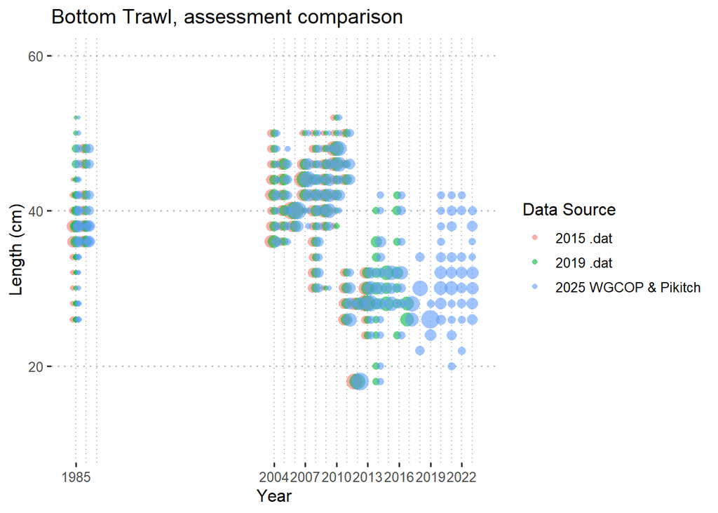

```r
# Plot all three assessment years' data same plot
print(bind_rows(length.comps.agg.2015.bt, length.comps.agg.2019.bt,
                length.comps.agg.bt %>% mutate(dat="2025 WGCOP & Pikitch")) %>%
  mutate(sex=as.factor(as.character(sex))) %>%
  mutate(sex_desc=as.factor(case_when(
    sex==0~"combined",
    sex==1~"female",
    sex==2~"male",
    sex==3~"joint distribution"))) %>%
  filter(prop_total>0) %>%
  ggplot(aes(x = year, y = variable, color = dat, size = prop_total)) +

  # Add vertical dotted lines at each unique x-axis year
  geom_vline(data = length.comps.agg.bt %>% distinct(year),
             aes(xintercept = year),
             linetype = "dotted", color = "gray50", alpha = 0.5) +

  # Plot points
  geom_point(shape = 16, position = position_dodge(0.85), alpha=0.6) +
  theme_pubclean() +
  ylim(c(10, 60)) +
  ylab("Length (cm)") +
  xlab("Year") +
  ggtitle("Bottom Trawl, assessment comparison") +
  scale_x_continuous(breaks = years_to_display) +
  theme(legend.position = "right") +
  guides(color = guide_legend(order=1, title = "Data Source"), size = "none"))
```

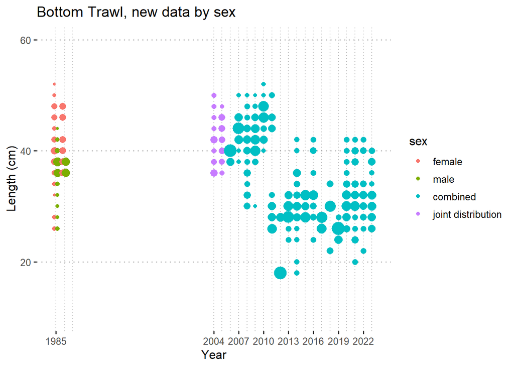

```r
# Plot just 2025 comps with sex data
print(length.comps.agg.bt %>% mutate(sex=as.factor(as.character(sex))) %>%
  mutate(sex_desc=as.factor(case_when(
    sex==0~"combined",
    sex==1~"female",
    sex==2~"male",
    sex==3~"joint distribution"))) %>%
  filter(prop_total>0) %>%
  ggplot(aes(x = year, y = variable, col = sex_desc, size = prop_total)) +

  # Add vertical dotted lines at each unique x-axis year
  geom_vline(data = length.comps.agg.bt %>% distinct(year),
             aes(xintercept = year),
             linetype = "dotted", color = "gray50", alpha = 0.5) +

  # Plot points
  geom_point(shape = 16, position = position_dodge(0.75)) +
  theme_pubclean() +
  ylim(c(10, 60)) +
  ylab("Length (cm)") +
  xlab("Year") +
  ggtitle("Bottom Trawl, new data by sex") +
  scale_x_continuous(breaks = years_to_display) +
  theme(legend.position = "right") +
  guides(color = guide_legend(order=1, title = "sex"), size = "none"))
```

### Hook & Line

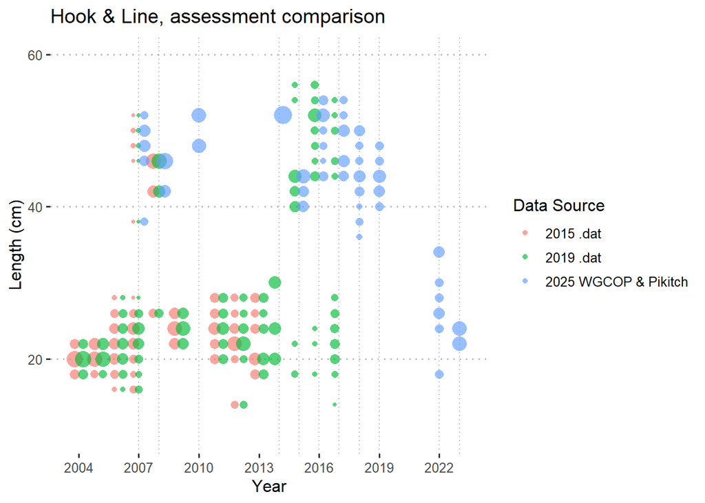

```r
length.comps.agg.hl <- length.comps %>%
  filter(fleet==5) %>%
  pivot_longer(cols = f8:m56, names_to = "variable", values_to = "prop") %>%
  filter(grepl("f", variable)) %>%
  mutate(variable=as.numeric(gsub("m|f","",variable))) %>%
  mutate(dat="2025 WGCOP & Pikitch")

# 2015 data retrieved from 2015 assessment Word doc (.dat file, starting at pg 181)
length.comps.agg.2015.hl <- read.csv(here("data_provided/2015_assessment", "2015_discard-length-data.csv"), col.names=names(length.comps.1980s)) %>%
  filter(part==1) %>% filter(year>0)  %>%
  filter(fleet==5) %>%
  pivot_longer(cols = f8:m56, names_to = "variable", values_to = "prop") %>%
  filter(grepl("f", variable)) %>%
  mutate(variable=as.numeric(gsub("m|f","",variable))) %>%
  mutate(dat="2015 .dat")

#2019 from .dat file
length.comps.agg.2019.hl <- ssdat.2019$lencomp %>%
  filter(part==1) %>% filter(year>0)  %>%
  filter(fleet==5) %>%
  pivot_longer(cols = f8:m56, names_to = "variable", values_to = "prop") %>%
  filter(grepl("f", variable)) %>%
  mutate(variable=as.numeric(gsub("m|f","",variable))) %>%
  mutate(dat="2019 .dat")


# Plot all three assessment years' data same plot
print(bind_rows(length.comps.agg.2015.hl, length.comps.agg.2019.hl,
                length.comps.agg.hl) %>%
  filter(prop>0) %>%
  ggplot(aes(x = year, y = variable, color = dat, size = prop)) +

  # Add vertical dotted lines at each unique x-axis year
  geom_vline(data = length.comps.agg.hl %>% distinct(year),
             aes(xintercept = year),
             linetype = "dotted", color = "gray50", alpha = 0.5) +

  # Plot points
  geom_point(shape = 16, position = position_dodge(0.85), alpha=0.65) +
  theme_pubclean() +
  ylim(c(10, 60)) +
  ylab("Length (cm)") +
  xlab("Year") +
  ggtitle("Hook & Line, assessment comparison") +
  scale_x_continuous(breaks = years_to_display) +
  theme(legend.position = "right") +
  guides(color = guide_legend(order=1, title = "Data Source"), size = "none"))
```

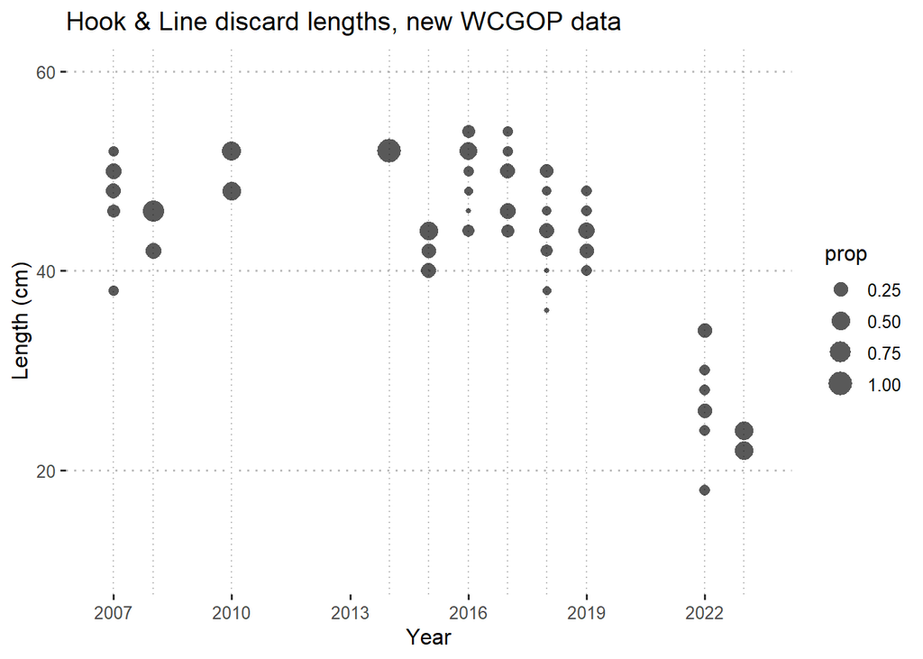

```r
# Plot just 2025 comps
print(length.comps.agg.hl %>%
  filter(prop>0) %>%
  ggplot(aes(x = year, y = variable, size = prop)) +

  # Add vertical dotted lines at each unique x-axis year
  geom_vline(data = length.comps.agg.hl %>% distinct(year),
             aes(xintercept = year),
             linetype = "dotted", color = "gray50", alpha = 0.5) +

  # Plot points
  geom_point(shape = 16, position = position_dodge(0.75), alpha=0.65) +
  theme_pubclean() +
  ylim(c(10, 60)) +
  ylab("Length (cm)") +
  xlab("Year") +
  ggtitle("Hook & Line discard lengths, new WCGOP data") +
  scale_x_continuous(breaks = years_to_display[-1]) +
  theme(legend.position = "right"))
```

## OPTION 2:

- Length comps through 2017 from the 2019 .dat file
- Add only new length comps (2018+) from new WCGOP data provided this year (2025)

Regarding the -2018 values from the 2019 .dat file, this is that the SS3 manual says:

“If the value of year is negative, then that observation is not transferred into the working array. This feature is the easiest way to include observations in a data file but not to use them in a particular model scenario.”

So, the previous authors wanted to keep the 2018 data since they had it in hand, but not include it in the run.

```r
length.comps.2019assess.opt2 <- ssdat.2019$lencomp %>% filter(part==1) %>% filter(year>0)

length.comps.new.opt2 <- bind_cols(
    read.csv(here("data_provided/wcgop", "biological_discard_lengths.csv"), col.names = names(length.comps.1980s)) %>% #use same names as .dat from 2019 for easy row binding
    filter(year>2017) %>% select(year:f56),
    read.csv(here("data_provided/wcgop", "biological_discard_lengths.csv"), col.names = names(length.comps.1980s)) %>% #use same names as .dat from 2019 for easy row binding
    filter(year>2017) %>% select(f8:f56) %>% rename_with(~ gsub("f", "m", .))) %>%
    mutate(month=7) %>%
    mutate(across(matches("^[f|m]\\d+"), ~ . / 100)) %>% # get into proportions to match the 2019 .dat file (currently percentage)
    mutate(fleet=case_when(
      fleet=="bottomtrawl-coastwide"~1,
      fleet=="midwaterrockfish-coastwide"~2,
      fleet=="midwaterhake-coastwide"~3,
      fleet=="hook-and-line-coastwide"~5)) %>%
    mutate(across(matches("^[f|m]\\d+"), ~ round(., 3))) #round

length.comps.updateonly <- bind_rows(length.comps.2019assess.opt2, length.comps.new.opt2)

# An alternative discard length comps file, should we want to only add the new years from the new WCGOP data file
write.csv(length.comps.updateonly %>% mutate(across(matches("^[f|m]\\d+"), ~ round(., 3))), file = here("data_derived/discards/discard_length_comps_add-years-only.csv"))
```